# Steak Preferences in the U.S.

Summary Report for the Pacific Region

Author: Ryan Jerving

Saturday, March 10, 2018

## Background

In May 2014, Walt Hickey at [538.com](http://fivethirtyeight.com/) published an article titled [“How Americans Like Their Steak.”](https://fivethirtyeight.com/features/how-americans-like-their-steak/) In this article, he utilized survey data collected from 550 people which asked questions related to various risky activities, such as whether they speed in traffic, if they smoke, if they skydive, and if they prefer a riskier-than-average lottery.

The survey also asked if they eat steak and, if so, how they prefer it to be cooked.

## Purpose

The “steak survey” dataset that was used for the [“How Americans Like Their Steak”](https://fivethirtyeight.com/features/how-americans-like-their-steak/) article is available through the R package [`fivethirtyeight`](https://cran.r-project.org/web/packages/fivethirtyeight/index.html).

Using this dataset, this article summarizes the steak preferences for the Pacific Region of the United States by gender.

For our summary presented here, a subset of the original steak survey was extracted to only include responses with no missing data and only included respondents from the Pacific region of the U.S. The data subset used for our summary had 57 respondents.

## Demographic Summary Tables

The age categories of the 57 survey respondents were:

Ages of Survey Respondents

| Ages | % |
| --- | --- |
| 18-29 | 14.04 |
| 30-44 | 24.56 |
| 45-60 | 31.58 |
| > 60 | 29.82 |

The education levels of the 57 survey respondents were:

Education of Survey Respondents

| Education | % |
| --- | --- |
| Less than high school degree | 1.75 |
| High school degree | 3.51 |
| Some college or Associate degree | 35.09 |
| Bachelor degree | 35.09 |
| Graduate degree | 24.56 |

The income levels of the 57 survey respondents were:

Income of Survey Respondents

| Income | % |
| --- | --- |
| $0 - $24,999 | 12.28 |
| $25,000 - $49,999 | 15.79 |
| $50,000 - $99,999 | 42.11 |
| $100,000 - $149,999 | 19.30 |
| $150,000+ | 10.53 |
| TRUE | 0.00 |

## *OPTIONAL* Demographics of Survey Respondents in a Merged Table

This section is provided as an example of how to merge the three demographic summary tables for the 57 survey respondents above into a single merged table.

Demographics of Survey Respondents

| Ages Category | Ages % | Education Category | Education % | Income Category | Income % |
| --- | --- | --- | --- | --- | --- |
| 18-29 | 14.04 | Less than high school degree | 1.75 | $0 - $24,999 | 12.28 |
| 30-44 | 24.56 | High school degree | 3.51 | $25,000 - $49,999 | 15.79 |
| 45-60 | 31.58 | Some college or Associate degree | 35.09 | $50,000 - $99,999 | 42.11 |
| > 60 | 29.82 | Bachelor degree | 35.09 | $100,000 - $149,999 | 19.30 |
|  |  | Graduate degree | 24.56 | $150,000+ | 10.53 |
|  |  |  |  | TRUE | 0.00 |

## Steak Preparation Preference by Gender

Finally, here is a breakdown of the 57 survey respondents for the Pacific region of the US on how they prefer their steak to be prepared by gender.

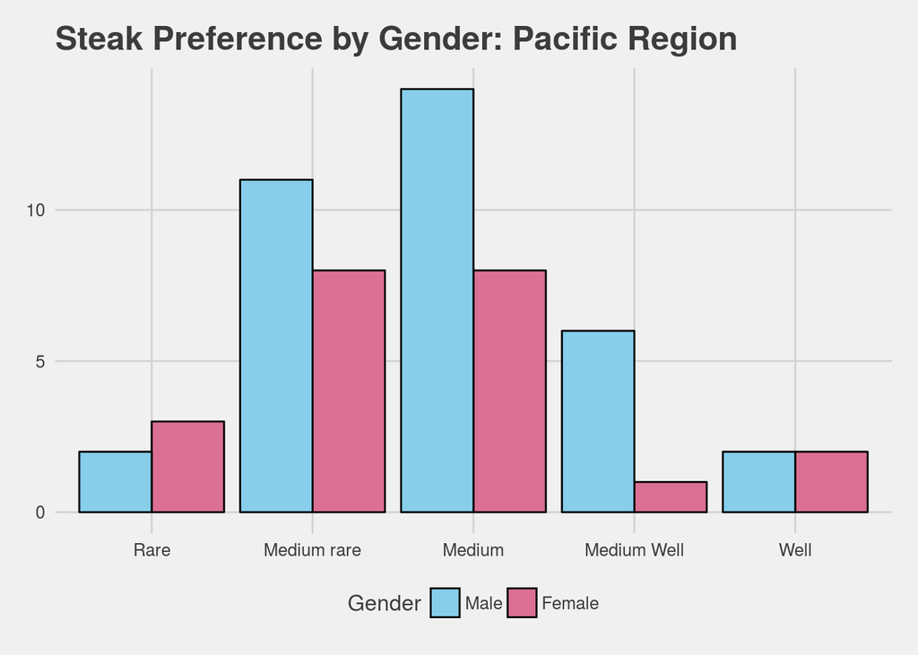